# Quality Activity Recognition

Sahil Behl

# Introduction

Using devices such as Jawbone Up, Nike FuelBand, and Fitbit it is now possible to collect a large amount of data about personal activity relatively inexpensively. These type of devices are part of the quantified self movement – a group of enthusiasts who take measurements about themselves regularly to improve their health, to find patterns in their behavior, or because they are tech geeks. One thing that people regularly do is quantify how much of a particular activity they do, but they rarely quantify how well they do it. In this analysis, the goal is to use data from accelerometers on the belt, forearm, arm, and dumbell of 6 participants. They were asked to perform barbell lifts correctly and incorrectly in 5 different ways. More information is available from the website here: [link](http://web.archive.org/web/20161224072740/http:/groupware.les.inf.puc-rio.br/har).

# Importing Data and PreProcessing

```r
trainingDatasetURL <- "https://d396qusza40orc.cloudfront.net/predmachlearn/pml-training.csv";
download.file(trainingDatasetURL,'training.csv',method = 'curl')
training_set <- read.csv('training.csv', na.strings=c("NA","#DIV/0!",""))

testingDatasetURL <- "https://d396qusza40orc.cloudfront.net/predmachlearn/pml-testing.csv";
download.file(testingDatasetURL,'test.csv',method = 'curl')
test_set <- read.csv('test.csv', na.strings=c("NA","#DIV/0!",""))
```

After data partition lets look at the dimensions of both training set and test set.

```r
dim(training_set)
```

```
## [1] 19622   160
```

```r
dim(test_set)
```

```
## [1]  20 160
```

Looking at varibles which remain almost zero variablilty. These variables/columns will not have effect on our prediction.

```r
nzv <- nearZeroVar(training_set, saveMetrics = TRUE)
```

Removing near zero varibles that we saw above

```r
training_set <- training_set[,!nzv$nzv]
test_set <- test_set[,!nzv$nzv]
dim(training_set)
```

```
## [1] 19622   124
```

```r
dim(test_set)
```

```
## [1]  20 124
```

### NA Values

The Columns that have almost all values NA will play no factor in prediction.

```r
x <- colSums(is.na(training_set))
x <- x[x > 10000]
NAvaribles <- names(training_set) %in% names(x)
training_set <- training_set[,!NAvaribles]
test_set <- test_set[,!NAvaribles]
dim(training_set)
```

```
## [1] 19622    59
```

```r
dim(test_set)
```

```
## [1] 20 59
```

# Model Building

Before Model Building the the first five columns of our training set can be removed because they will play not part.

```r
training_set <- training_set[,6:59]
test_set <- test_set[,6:59]
dim(training_set)
```

```
## [1] 19622    54
```

```r
dim(test_set)
```

```
## [1] 20 54
```

So that there is no bias while we training our model using test set we further divide our training_set into validation and train set.

```r
set.seed(123)
split = sample.split(training_set$roll_belt, SplitRatio = 0.8)
train = subset(training_set, split == TRUE)
validate = subset(training_set, split == FALSE)
dim(train)
```

```
## [1] 15877    54
```

```r
dim(validate)
```

```
## [1] 3745   54
```

The first model we choose is decision tree to train.

```r
model1 <- rpart(classe ~ ., data = train)
y_pred <- predict(model1, newdata = validate, type = 'class')
cmtree1 <- confusionMatrix(y_pred, validate$classe)
print(cmtree1)
```

```
## Confusion Matrix and Statistics
##
##           Reference
## Prediction   A   B   C   D   E
##          A 993  72   2  14   1
##          B  51 550  49  38  35
##          C   1  35 578  15   0
##          D  57  46  76 462  38
##          E  18  38  14  39 523
##
## Overall Statistics
##
##                Accuracy : 0.8294
##                  95% CI : (0.8169, 0.8413)
##     No Information Rate : 0.2991
##     P-Value [Acc > NIR] : < 2.2e-16
##
##                   Kappa : 0.7837
##  Mcnemar's Test P-Value : < 2.2e-16
##
## Statistics by Class:
##
##                      Class: A Class: B Class: C Class: D Class: E
## Sensitivity            0.8866   0.7422   0.8039   0.8134   0.8760
## Specificity            0.9661   0.9424   0.9831   0.9317   0.9654
## Pos Pred Value         0.9177   0.7607   0.9189   0.6804   0.8275
## Neg Pred Value         0.9523   0.9368   0.9547   0.9654   0.9762
## Prevalence             0.2991   0.1979   0.1920   0.1517   0.1594
## Detection Rate         0.2652   0.1469   0.1543   0.1234   0.1397
## Detection Prevalence   0.2889   0.1931   0.1680   0.1813   0.1688
## Balanced Accuracy      0.9264   0.8423   0.8935   0.8725   0.9207
```

The decision tree can be drawn below:

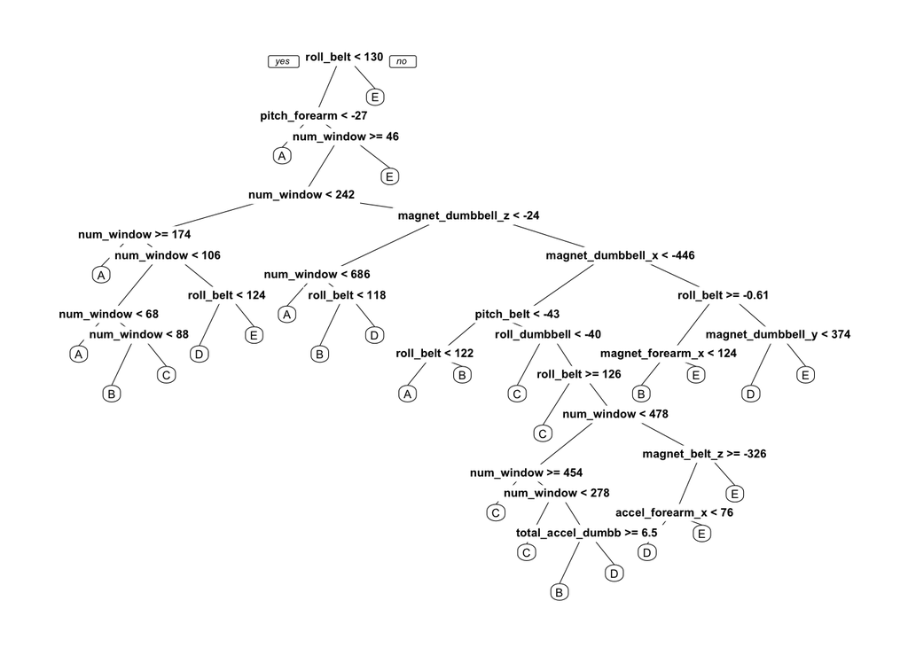

```r
prp(model1)
```

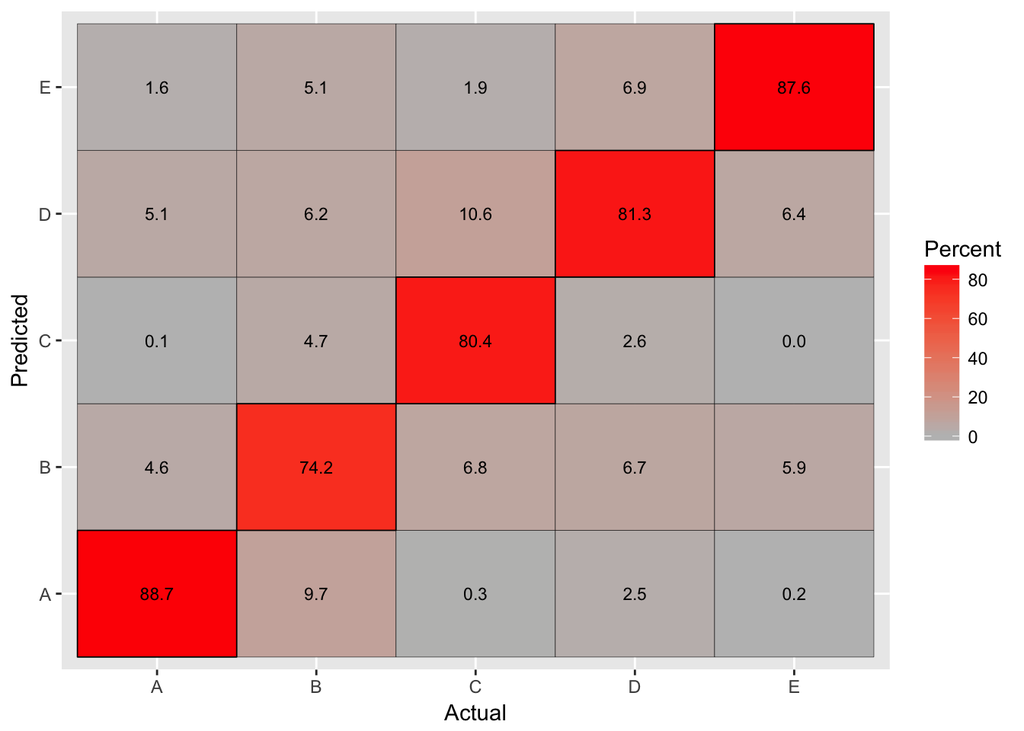

```r
#get data
data = data.frame(validate$classe, y_pred)
names(data) = c("Actual", "Predicted")

#compute frequency of actual categories
actual = as.data.frame(table(data$Actual))
names(actual) = c("Actual","ActualFreq")

#build confusion matrix
confusion = as.data.frame(table(data$Actual, data$Predicted))
names(confusion) = c("Actual","Predicted","Freq")

#calculate percentage of test cases based on actual frequency
confusion = merge(confusion, actual)
confusion$Percent = confusion$Freq/confusion$ActualFreq*100

#render plot
# we use three different layers
# first we draw tiles and fill color based on percentage of test cases
tile <- ggplot() +
      geom_tile(aes(x=Actual, y=Predicted,fill=Percent),data=confusion, color="black",size=0.1) +
      labs(x="Actual",y="Predicted")
tile = tile +
      geom_text(aes(x=Actual,y=Predicted, label=sprintf("%.1f", Percent)),data=confusion, size=3, colour="black") +
      scale_fill_gradient(low="grey",high="red")

# lastly we draw diagonal tiles. We use alpha = 0 so as not to hide previous layers but use size=0.3 to highlight border
tile = tile +
      geom_tile(aes(x=Actual,y=Predicted),data=subset(confusion, as.character(Actual)==as.character(Predicted)), color="black",size=0.3, fill="black", alpha=0)

#render
tile
```

The next model we try is random forest

```r
model2 <- randomForest(formula = classe ~ .,data = train,ntree = 5)
y_pred <- predict(model2, newdata = validate, type = 'class')
cmtree2 <- confusionMatrix(y_pred, validate$classe)
print(cmtree2)
```

```
## Confusion Matrix and Statistics
##
##           Reference
## Prediction    A    B    C    D    E
##          A 1115    7    0    0    0
##          B    4  724   12    0    3
##          C    0    8  705    3    1
##          D    1    2    2  565    4
##          E    0    0    0    0  589
##
## Overall Statistics
##
##                Accuracy : 0.9874
##                  95% CI : (0.9833, 0.9908)
##     No Information Rate : 0.2991
##     P-Value [Acc > NIR] : < 2.2e-16
##
##                   Kappa : 0.984
##  Mcnemar's Test P-Value : NA
##
## Statistics by Class:
##
##                      Class: A Class: B Class: C Class: D Class: E
## Sensitivity            0.9955   0.9771   0.9805   0.9947   0.9866
## Specificity            0.9973   0.9937   0.9960   0.9972   1.0000
## Pos Pred Value         0.9938   0.9744   0.9833   0.9843   1.0000
## Neg Pred Value         0.9981   0.9943   0.9954   0.9991   0.9975
## Prevalence             0.2991   0.1979   0.1920   0.1517   0.1594
## Detection Rate         0.2977   0.1933   0.1883   0.1509   0.1573
## Detection Prevalence   0.2996   0.1984   0.1915   0.1533   0.1573
## Balanced Accuracy      0.9964   0.9854   0.9883   0.9959   0.9933
```

The Confustion matrix can be seen below

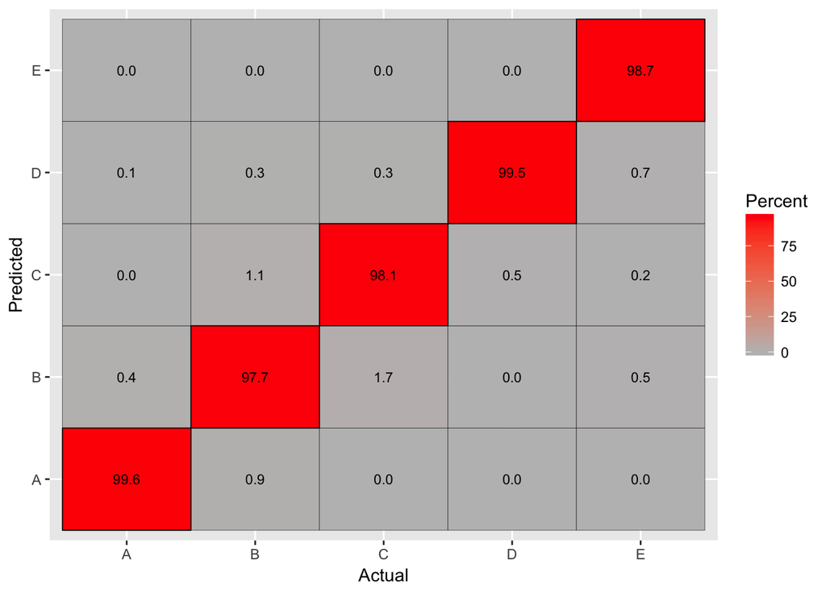

```r
data = data.frame(validate$classe, y_pred)
names(data) = c("Actual", "Predicted")

#compute frequency of actual categories
actual = as.data.frame(table(data$Actual))
names(actual) = c("Actual","ActualFreq")

#build confusion matrix
confusion = as.data.frame(table(data$Actual, data$Predicted))
names(confusion) = c("Actual","Predicted","Freq")

#calculate percentage of test cases based on actual frequency
confusion = merge(confusion, actual)
confusion$Percent = confusion$Freq/confusion$ActualFreq*100

#render plot
# we use three different layers
# first we draw tiles and fill color based on percentage of test cases
tile <- ggplot() +
      geom_tile(aes(x=Actual, y=Predicted,fill=Percent),data=confusion, color="black",size=0.1) +
      labs(x="Actual",y="Predicted")
tile = tile +
      geom_text(aes(x=Actual,y=Predicted, label=sprintf("%.1f", Percent)),data=confusion, size=3, colour="black") +
      scale_fill_gradient(low="grey",high="red")

# lastly we draw diagonal tiles. We use alpha = 0 so as not to hide previous layers but use size=0.3 to highlight border
tile = tile +
      geom_tile(aes(x=Actual,y=Predicted),data=subset(confusion, as.character(Actual)==as.character(Predicted)), color="black",size=0.3, fill="black", alpha=0)

#render
tile
```

```r
AccuracyResults <- data.frame(
      Model = c('Decision Tree', 'Random Forest'),
      Accuracy = rbind(cmtree1$overall[1], cmtree2$overall[1])
)
```

The relative importance of each columns can be seen below for building model

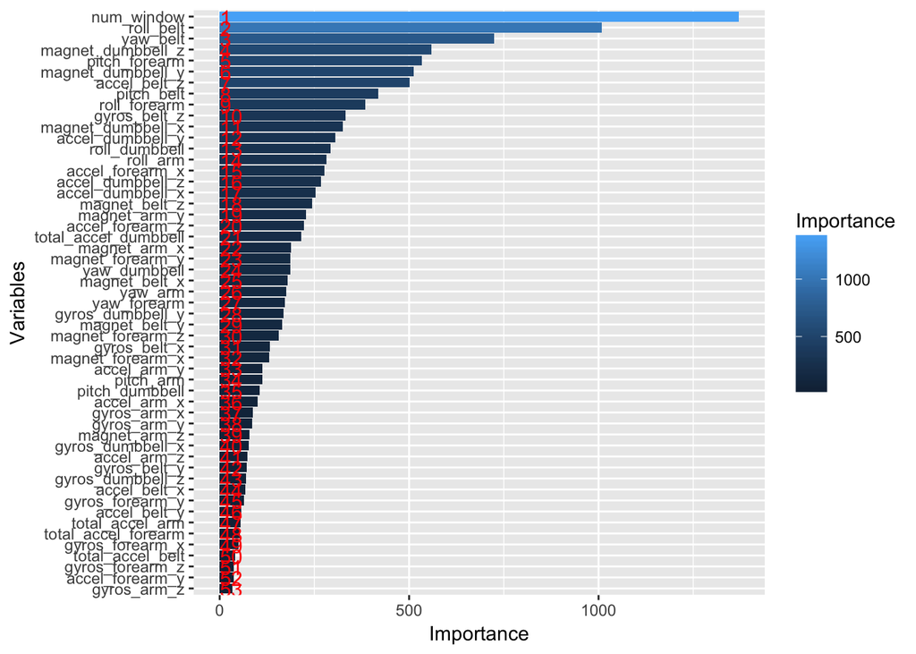

```r
importance    <- importance(model2)
varImportance <- data.frame(Variables = row.names(importance),
                            Importance = round(importance[ ,'MeanDecreaseGini'],2))

#Create a rank variable based on importance
rankImportance <- varImportance %>%
      mutate(Rank = dense_rank(desc(Importance)))

#Use ggplot2 to visualize the relative importance of variables
library(ggplot2)
ggplot(rankImportance, aes(x = reorder(Variables, Importance),
                           y = Importance, fill = Importance)) +
      geom_bar(stat='identity') +
      geom_text(aes(x = Variables, y = 0.5, label = Rank),
                hjust=0, vjust=0.55, size = 4, colour = 'red') +
      labs(x = 'Variables') +
      coord_flip()
```

```r
selectedColumns <- rankImportance[order(rankImportance$Rank,rankImportance$Variables),1]
selectedColumns <- selectedColumns[1:15]
selectedColumns <- union(selectedColumns,c("classe"))
print(selectedColumns)
```

```
##  [1] "num_window"        "roll_belt"         "yaw_belt"
##  [4] "magnet_dumbbell_z" "pitch_forearm"     "magnet_dumbbell_y"
##  [7] "accel_belt_z"      "pitch_belt"        "roll_forearm"
## [10] "gyros_belt_z"      "magnet_dumbbell_x" "accel_dumbbell_y"
## [13] "roll_dumbbell"     "roll_arm"          "accel_forearm_x"
## [16] "classe"
```

```r
selectedColumns <- as.array(selectedColumns)
```

```r
selectedTraining <- training_set[,c("roll_belt","yaw_belt","magnet_dumbbell_z","roll_forearm","pitch_belt","magnet_dumbbell_y","pitch_forearm","magnet_belt_z","magnet_dumbbell_x","roll_dumbbell","magnet_belt_y","accel_forearm_x","gyros_belt_z","magnet_forearm_z","accel_dumbbell_z","classe" )]
dim(selectedTraining)
```

```
## [1] 19622    16
```

```r
finalModel <- randomForest(classe ~ ., data = selectedTraining, ntree = 5)
```

# Prediction

```r
test_set <- test_set[,c("roll_belt","yaw_belt","magnet_dumbbell_z","roll_forearm","pitch_belt","magnet_dumbbell_y","pitch_forearm","magnet_belt_z","magnet_dumbbell_x","roll_dumbbell","magnet_belt_y","accel_forearm_x","gyros_belt_z","magnet_forearm_z","accel_dumbbell_z")]
final_prediction <- predict(finalModel, newdata = test_set, type = 'class')
print(final_prediction)
```

```
##  1  2  3  4  5  6  7  8  9 10 11 12 13 14 15 16 17 18 19 20
##  B  A  B  A  A  E  D  B  A  A  B  C  B  A  E  E  A  B  B  B
## Levels: A B C D E
```